# Analysis of Red Wine Chemical Attributes by Javier Ortiz

# Bivariate Analysis

### Talk about some of the relationships you observed in this part of the investigation. How did the feature(s) of interest vary with other features in the dataset?

Some of the relationships I observed were about quality against different features: alcohol, volatile acidity, chlorides, sulphates and citric acid. Even though most of the scatterplots showed a trend that links these various features with quality, the correlations were non-significant and the trends too weak, with the exception of alcohol and quality.

### Did you observe any interesting relationships between the other features (not the main feature(s) of interest)?

Yes, I had the idea that really sweet wines had a higher alcohol content. The scatterplot not only debunked this myth, since most wines are not that sweet regardless of their alcohol content, but out of those wines that are sweet, they usually have a low alcohol content.

### What was the strongest relationship you found?

The strongest relationship I found is between alcohol and quality. The correlation test came out with a result of 0.476 which is a moderate but significant correlation, and when comparing the alcohol content means across quality, the high quality wines have a signficant higher alcohol content than low quality wines.

# Multivariate Plots Section

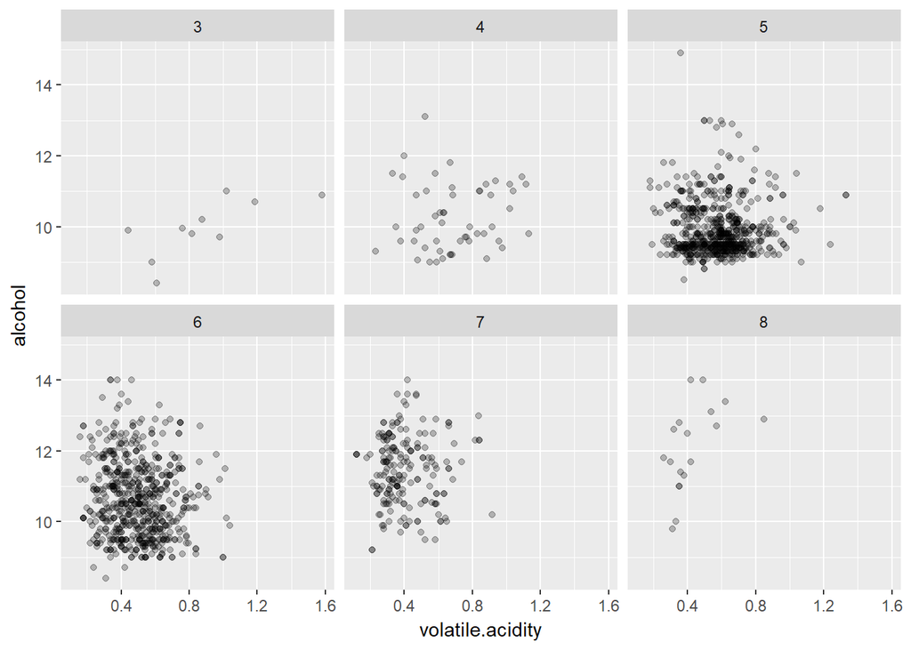

Here we have a graph for each quality ranking that describes the relationship between alcohol and volatile.acidity. Low quality wines have a low alcohol content and a relatively high volatile acidity. On the other hand, high quality wines have a higher alcohol content and a lower volatile acidity.

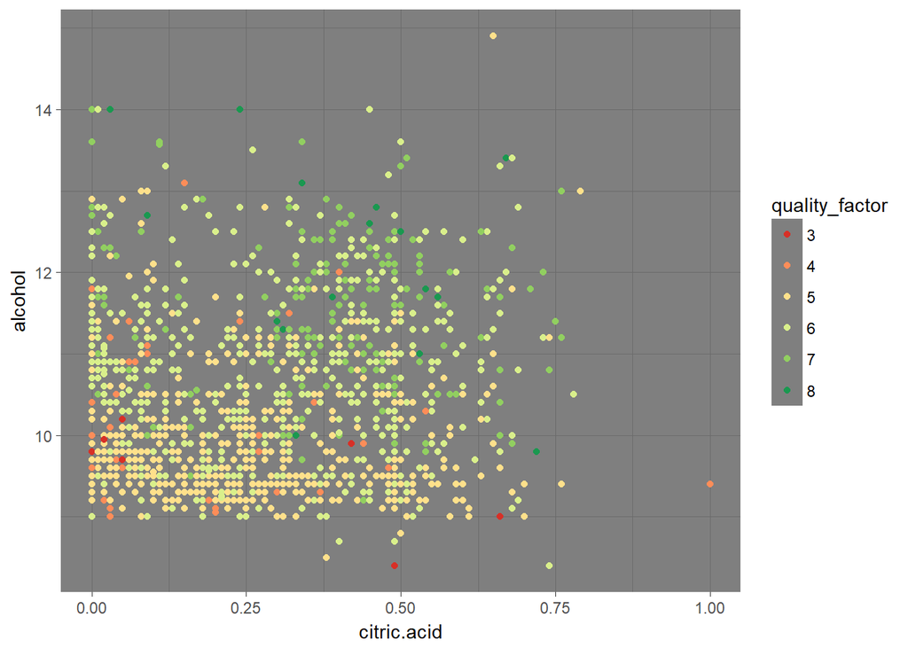

This graph shows the relation of alcohol and citric acid for each quality level. High quality wines have a higher alcohol content with medium levels of citric acid.

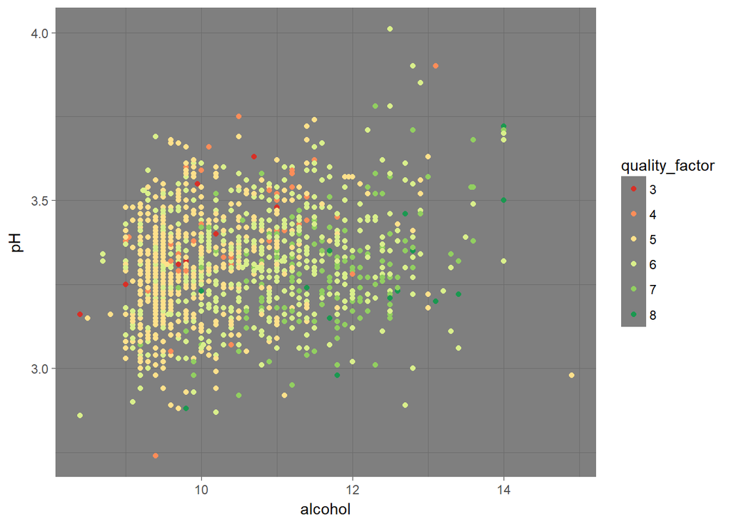

Nothing particular stands out.

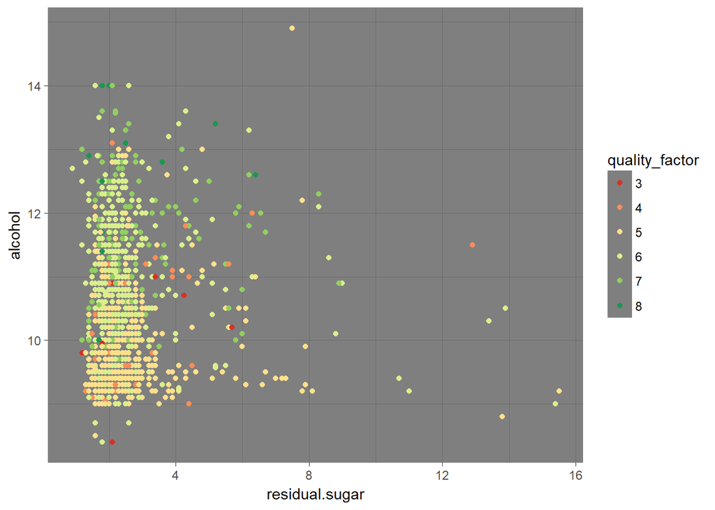

This graph confirms that the sweetest wines have the lowest alcohol content and also that high quality wines tend to have low levels for residual sugar.

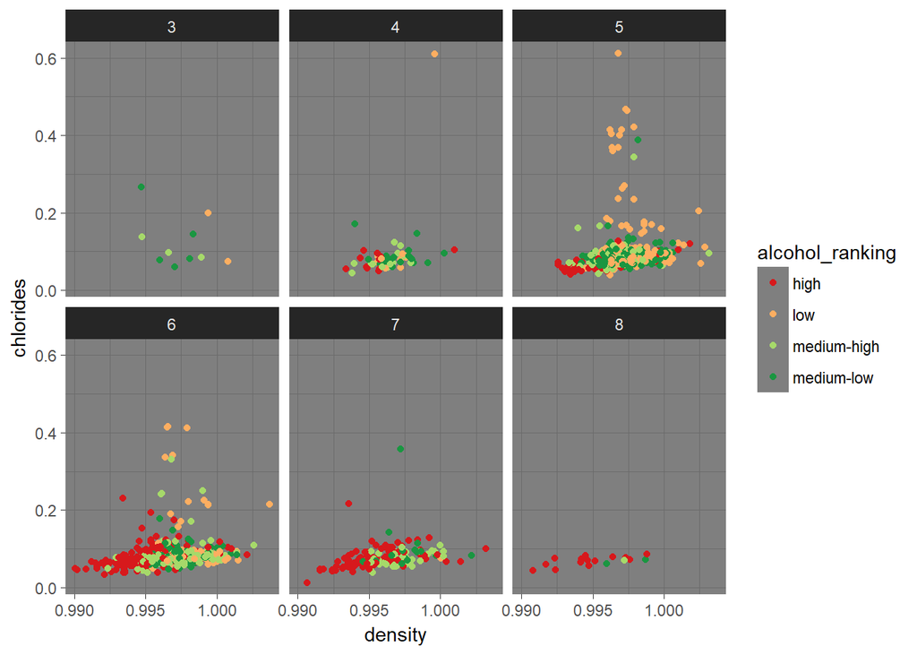

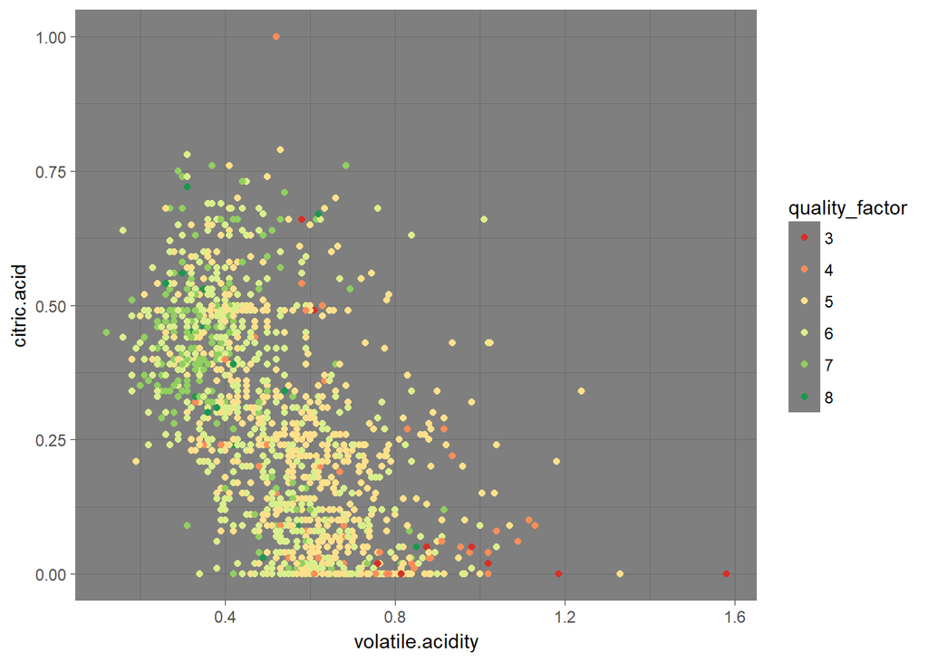

There is a clear trend that establishes a relationship between citric acid and volatile acidity. When levels of citric acid are high, volatile acidity tends to be low, this is specially true in high quality wines. The opposite is also true, when volatile acidity is high, citric acid tends to be low, this happens more often with lower quality wines.

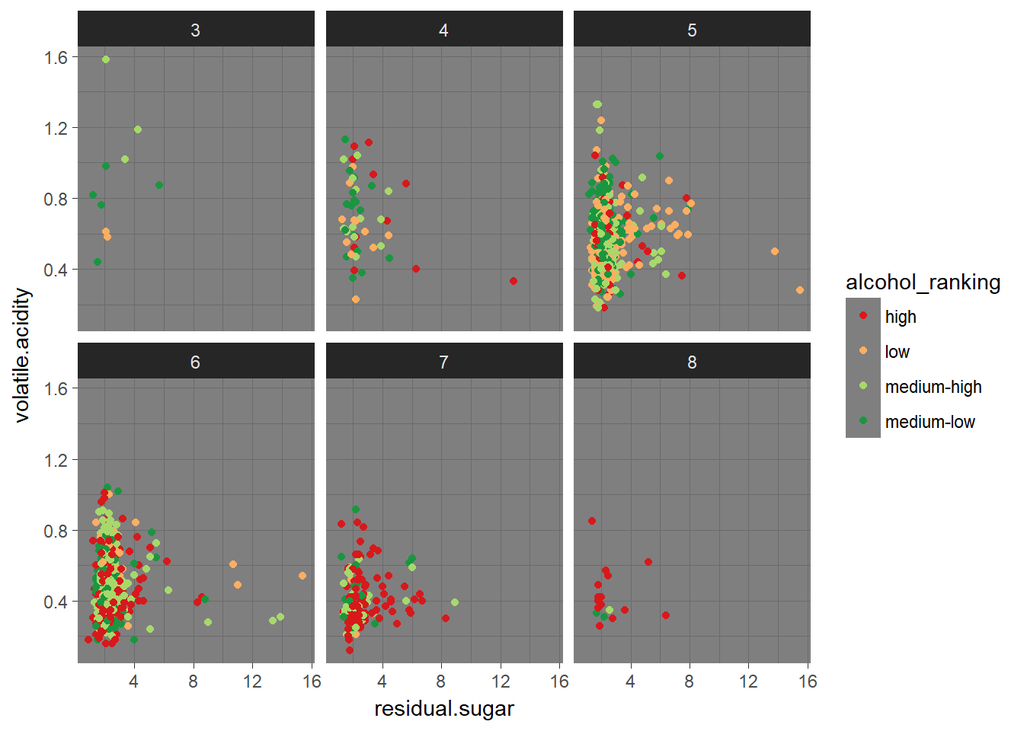

# Multivariate Analysis

### Talk about some of the relationships you observed in this part of the investigation. Were there features that strengthened each other in terms of looking at your feature(s) of interest?

For this section, I already had a clear idea that alcohol content was the most important feature in determining the quality of wine. So I focused my attention on describing the relationship of alcohol with other features of the dataset. High quality wines (which have high alcohol content), have low levels for volatile acidity and medium levels for citric acid. Another interesting relationship is that of high quality wines and residual sugar, that shows that high quality wines have a low content of residual sugar, thus describing a high quality wine that is high in alcohol content and dry regarding its residual sugar.

# Final Plots and Summary

### Plot One

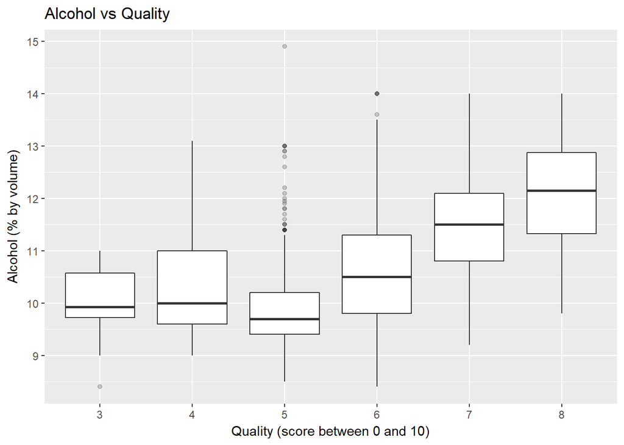

### Description One

This graph shows the strongest relationship I found in the dataset: Alcohol and Quality. If we follow the means of each quality distribution, we can see a clear trend that starts at quality level 5, where the alcohol content increases as the quality improves. As a result, wines with a quality of 6 have a higher alcohol content than wines with a quality of 5, wines with a quality of 7 have even higher alcohol content, and wines with a quality of 8 have the highest alcohol content of the sample. It is also clear that for the highest quality wines with a quality ranking #8, the bulk of the distribution (interquantile range) has a higher alcohol content than that of the entire distribution of wines with quality ranking #3.

### Plot Two

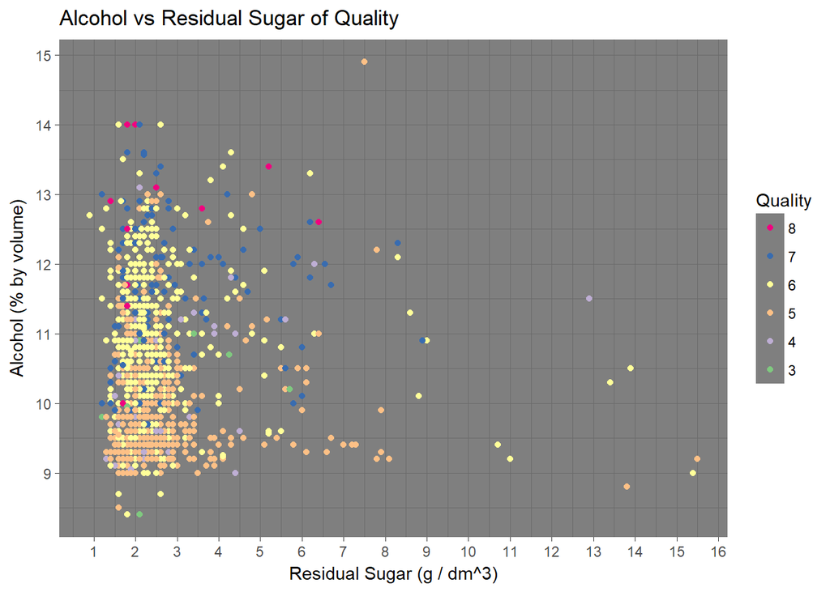

### Description Two

I like this plot because it weakens the myth that sweet wines have a high alcohol content. Most wines, regardless of their quality, have a residual sugar level of 4g/l, that categorizes them as dry. This is specially true with high quality wines with a ranking of 8, since most of the distribution is below this parameter. It is also clear that quality ranking #7 and #5 have the highest number of observations in the medium-dry range which covers from 4g/l up to 12g/l. We can only observe a couple of wines with a quality of 8 in this category. Finally, in the sweetest wines in this plot, above 12g/l which is considered a medium sweetness, we don’t have any observations of quality #8 wines.

### Plot Three

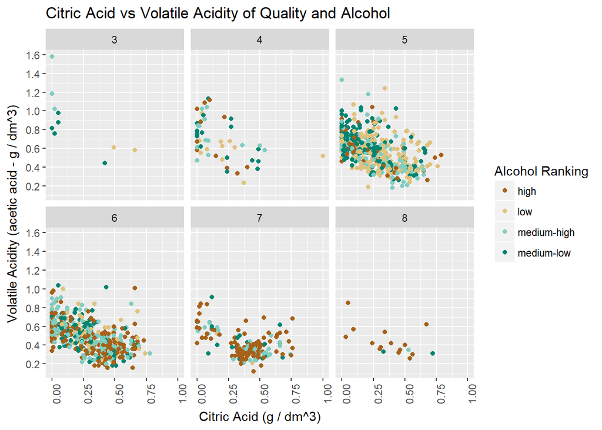

### Description Three

This graph shows the relationship between volatile acidity and citric acid by comparing the different alcohol rankings across the different quality rankings. For low quality wines such as #3, is has become clear that they have a lower alcohol content since there are no observations of wines with a high alcohol content in that quality ranking. Furthermore, low quality wines seem to have a higher value for volatile acidity and lower values for citric acid. When comparing quality rankings #3 against #8, this becomes obvious: While quality ranking #3 has most of their observations with a value above .8 for volatile acidity, quality ranking #8 has most of its observations with a value below .6 for volatile acidity; while quality ranking #3 has most of its observations with a value below .25 for citric acid, quality ranking #8 has most of its observations with a value above .25 for citric acid. All quality rankings follow the trend that when volatile acidity is high, citric acid is low; and when volatile acidity is low, citric acid is high.

# Reflection

Here I list some of the key insights found through this exploration.

The sample follows a normal distribution for quality, with most wines having a quality of 5 or 6. One surprising of the dataset is that there wasn’t a single observation below 3 or above a quality of 8.

Alcohol content proved to be one of the most important features when determining if a wine is high quality. According to the sample, most high quality wine have a high alcohol content while most of the low quality wines have also a low alcohol content.

One interesting relationship is that between alcohol content and residual sugar. Some people think that the sweeter the wine the more alcohol it has. It turns out this is not true, but opposite is. Most of the wines with high quality have lower levels of residual sugar, and from those wines that have a high level of residual sugar, they are usually pretty low in alcohol.

It also was really interesting to observe how the relation between different variables changed in each quality category. For example, volatile acidity and citric acid experience a constant trend throughout the data set where if volatile acidity increases, citric acid decreases and also the opposite. This became more obvious with high quality wines that have a much lower level of volatile acidity, thus, higher levels of citric acid.

One of the main struggles is quantity of variables that affect the quality of wine. Since there are so many, any subtle difference could change the quality of the wine dramatically, so it was really difficult to establish trends among the entire sample.

In the future it could be really interesting to add the type of red wine that is being graded, since that could change the rating dramatically since one is looking for different characteristics when tasting a cabernet sauvignon to a zinfandel for example. Having some wines with a quality of 9 or 10 could also be really interesting and perhaps help establish stronger trends in the data.